# AmesHousingData

25 March 2018

## Exploratory data analysis

```r
library(tidyverse)
library(rapportools)
library(ggplot2)
library(pryr)
library(fastDummies)
library(gridExtra)
library(broom)
library(glmnet)
library(cowplot)
library(gbm)
library(pcaMethods)
library(vegan)
library(cluster)
library(fpc)
library(DataExplorer)
library(ggfortify)
library(devtools)
install_github("vqv/ggbiplot")
library(ggbiplot)
```

#### Accessing the data

```r
AmesURL <- 'https://www.openintro.org/stat/data/ames.csv'
Ames <- read.csv(url(AmesURL), sep = ",", header = TRUE, stringsAsFactors = FALSE)
names(Ames) <- gsub('\\.', '', names(Ames))
```

#### Dimensions of the data

```r
dim(Ames)
```

```
## [1] 2930   82
```

#### Identify the outliers in the original data set.We can see 5 outliers in the below plot.

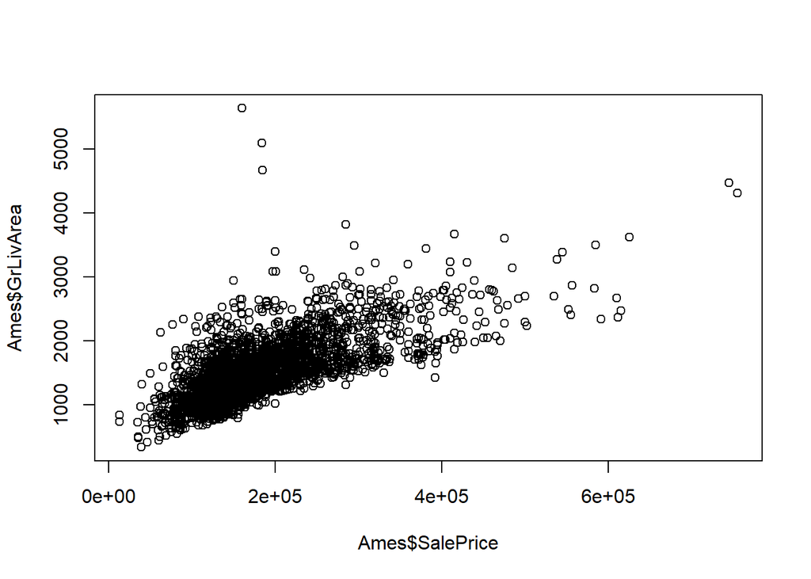

```r
plot(Ames$SalePrice, Ames$GrLivArea)
```

#### Remove the outliers in the data set

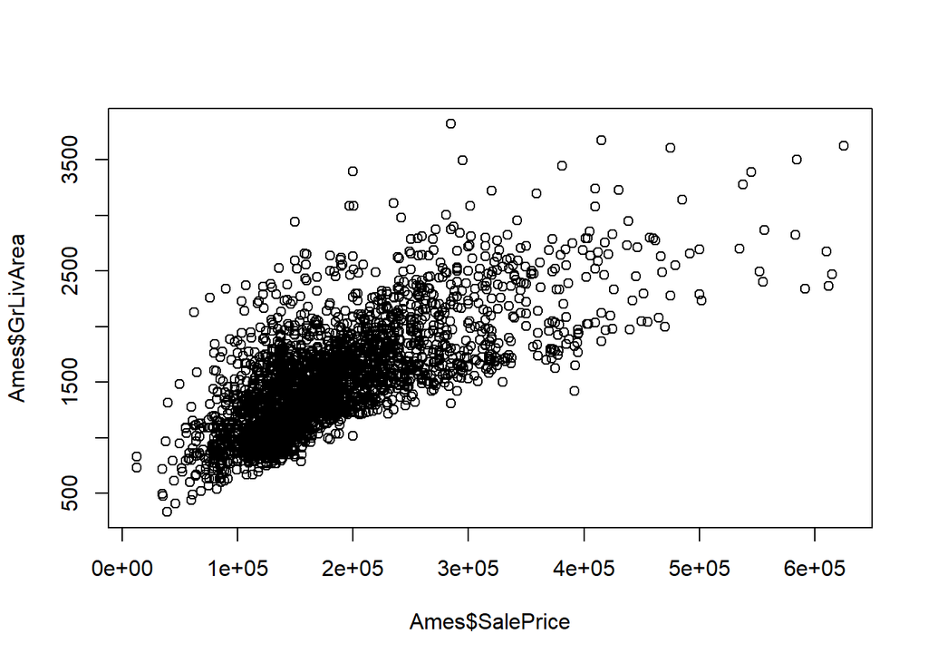

```r
Ames <- Ames[-c(1499, 2181, 2182, 1761, 1768), ]
plot(Ames$SalePrice, Ames$GrLivArea)
```

#### Below are some of the characteristics of data set like the dimensions,size and statistics.

```r
dim(Ames)
```

```
## [1] 2925   82
```

```r
object_size(Ames)
```

```
## 1.49 MB
```

```r
summary(Ames)
```

```
##      Order           PID              MSSubClass      MSZoning
##  Min.   :   1   Min.   :5.263e+08   Min.   : 20.0   Length:2925
##  1st Qu.: 732   1st Qu.:5.285e+08   1st Qu.: 20.0   Class :character
##  Median :1463   Median :5.355e+08   Median : 50.0   Mode  :character
##  Mean   :1465   Mean   :7.144e+08   Mean   : 57.4
##  3rd Qu.:2199   3rd Qu.:9.072e+08   3rd Qu.: 70.0
##  Max.   :2930   Max.   :1.007e+09   Max.   :190.0
##
##   LotFrontage        LotArea          Street             Alley
##  Min.   : 21.00   Min.   :  1300   Length:2925        Length:2925
##  1st Qu.: 58.00   1st Qu.:  7438   Class :character   Class :character
##  Median : 68.00   Median :  9428   Mode  :character   Mode  :character
##  Mean   : 69.02   Mean   : 10104
##  3rd Qu.: 80.00   3rd Qu.: 11515
##  Max.   :313.00   Max.   :215245
##  NA's   :490
##    LotShape         LandContour         Utilities
##  Length:2925        Length:2925        Length:2925
##  Class :character   Class :character   Class :character
##  Mode  :character   Mode  :character   Mode  :character
##
##
##
##
##   LotConfig          LandSlope         Neighborhood
##  Length:2925        Length:2925        Length:2925
##  Class :character   Class :character   Class :character
##  Mode  :character   Mode  :character   Mode  :character
##
##
##
##
##   Condition1         Condition2          BldgType
##  Length:2925        Length:2925        Length:2925
##  Class :character   Class :character   Class :character
##  Mode  :character   Mode  :character   Mode  :character
##
##
##
##
```

[output cut: 121 more lines]

```
##  Length:2925        Min.   :    0.00   Min.   : 1.000   Min.   :2006
##  Class :character   1st Qu.:    0.00   1st Qu.: 4.000   1st Qu.:2007
##  Mode  :character   Median :    0.00   Median : 6.000   Median :2008
##                     Mean   :   44.91   Mean   : 6.217   Mean   :2008
##                     3rd Qu.:    0.00   3rd Qu.: 8.000   3rd Qu.:2009
##                     Max.   :15500.00   Max.   :12.000   Max.   :2010
##
##    SaleType         SaleCondition        SalePrice
##  Length:2925        Length:2925        Min.   : 12789
##  Class :character   Class :character   1st Qu.:129500
##  Mode  :character   Mode  :character   Median :160000
##                                        Mean   :180412
##                                        3rd Qu.:213500
##                                        Max.   :625000
##
```

#### By checking the data structure of the data set we identify the integers and characters of the data set.

```r
str(Ames)
```

```
## 'data.frame':    2925 obs. of  82 variables:
##  $ Order        : int  1 2 3 4 5 6 7 8 9 10 ...
##  $ PID          : int  526301100 526350040 526351010 526353030 527105010 527105030 527127150 527145080 527146030 527162130 ...
##  $ MSSubClass   : int  20 20 20 20 60 60 120 120 120 60 ...
##  $ MSZoning     : chr  "RL" "RH" "RL" "RL" ...
##  $ LotFrontage  : int  141 80 81 93 74 78 41 43 39 60 ...
##  $ LotArea      : int  31770 11622 14267 11160 13830 9978 4920 5005 5389 7500 ...
##  $ Street       : chr  "Pave" "Pave" "Pave" "Pave" ...
##  $ Alley        : chr  NA NA NA NA ...
##  $ LotShape     : chr  "IR1" "Reg" "IR1" "Reg" ...
##  $ LandContour  : chr  "Lvl" "Lvl" "Lvl" "Lvl" ...
##  $ Utilities    : chr  "AllPub" "AllPub" "AllPub" "AllPub" ...
##  $ LotConfig    : chr  "Corner" "Inside" "Corner" "Corner" ...
##  $ LandSlope    : chr  "Gtl" "Gtl" "Gtl" "Gtl" ...
##  $ Neighborhood : chr  "NAmes" "NAmes" "NAmes" "NAmes" ...
```

[output cut: 68 more lines]

#### To check for the NA values and empty cells in the data set.

```r
sum(is.na(Ames))
```

```
## [1] 13944
```

```r
sum(is.empty(Ames))
```

```
## [1] 48760
```

#### To check for the totals NA’s in each feature and filter the numeric values of the dataset.

```r
nan_sums <- colSums(is.na(Ames))
nan_sums[nan_sums > 0]
```

```
##  LotFrontage        Alley   MasVnrArea     BsmtQual     BsmtCond
##          490         2727           23           79           79
## BsmtExposure BsmtFinType1   BsmtFinSF1 BsmtFinType2   BsmtFinSF2
##           79           79            1           79            1
##    BsmtUnfSF  TotalBsmtSF BsmtFullBath BsmtHalfBath  FireplaceQu
##            1            1            2            2         1422
##   GarageType  GarageYrBlt GarageFinish   GarageCars   GarageArea
##          157          159          157            1            1
##   GarageQual   GarageCond       PoolQC        Fence  MiscFeature
##          158          158         2914         2354         2820
```

#### Filter the numeric values in the dataset.

```r
Num <- str(Filter(is.numeric, Ames))
```

```
## 'data.frame':    2925 obs. of  39 variables:
##  $ Order        : int  1 2 3 4 5 6 7 8 9 10 ...
##  $ PID          : int  526301100 526350040 526351010 526353030 527105010 527105030 527127150 527145080 527146030 527162130 ...
##  $ MSSubClass   : int  20 20 20 20 60 60 120 120 120 60 ...
##  $ LotFrontage  : int  141 80 81 93 74 78 41 43 39 60 ...
##  $ LotArea      : int  31770 11622 14267 11160 13830 9978 4920 5005 5389 7500 ...
##  $ OverallQual  : int  6 5 6 7 5 6 8 8 8 7 ...
##  $ OverallCond  : int  5 6 6 5 5 6 5 5 5 5 ...
##  $ YearBuilt    : int  1960 1961 1958 1968 1997 1998 2001 1992 1995 1999 ...
##  $ YearRemodAdd : int  1960 1961 1958 1968 1998 1998 2001 1992 1996 1999 ...
##  $ MasVnrArea   : int  112 0 108 0 0 20 0 0 0 0 ...
##  $ BsmtFinSF1   : int  639 468 923 1065 791 602 616 263 1180 0 ...
##  $ BsmtFinSF2   : int  0 144 0 0 0 0 0 0 0 0 ...
##  $ BsmtUnfSF    : int  441 270 406 1045 137 324 722 1017 415 994 ...
##  $ TotalBsmtSF  : int  1080 882 1329 2110 928 926 1338 1280 1595 994 ...
```

[output cut: 25 more lines]

```r
sum(is.nan(Num))
```

```
## [1] 0
```

#### We can eliminate the NA’s by replacing with the median value of the column.

```r
medianLotFrontage <- median(Ames$LotFrontage, na.rm = TRUE)
medianMasVnrArea <- median(Ames$MasVnrArea, na.rm = TRUE)
medianBsmtFinSF1 <- median(Ames$BsmtFinSF1, na.rm = TRUE)
medianBsmtFinSF2 <- median(Ames$BsmtFinSF2, na.rm = TRUE)
medianBsmtUnfSF <- median(Ames$BsmtUnfSF, na.rm = TRUE)
medianTotalBsmtSF <- median(Ames$TotalBsmtSF, na.rm = TRUE)
medianGarageYrBlt <- median(Ames$GarageYrBlt, na.rm = TRUE)
medianGarageArea <- median(Ames$GarageArea, na.rm = TRUE)

Ames$LotFrontage[is.na(Ames$LotFrontage)] <- medianLotFrontage
Ames$MasVnrArea[is.na(Ames$MasVnrArea)] <- medianMasVnrArea
Ames$BsmtFinSF1[is.na(Ames$BsmtFinSF1)] <- medianBsmtFinSF1
Ames$BsmtFinSF2[is.na(Ames$BsmtFinSF2)] <- medianBsmtFinSF2
Ames$BsmtUnfSF[is.na(Ames$BsmtUnfSF)] <- medianBsmtUnfSF
Ames$TotalBsmtSF[is.na(Ames$TotalBsmtSF)] <- medianTotalBsmtSF
Ames$GarageYrBlt[is.na(Ames$GarageYrBlt)] <- medianGarageYrBlt
Ames$GarageArea[is.na(Ames$GarageArea)] <- medianGarageArea
```

```r
nan_sums <- colSums(is.na(Ames))
nan_sums[nan_sums > 0]
```

```
##        Alley     BsmtQual     BsmtCond BsmtExposure BsmtFinType1
##         2727           79           79           79           79
## BsmtFinType2 BsmtFullBath BsmtHalfBath  FireplaceQu   GarageType
##           79            2            2         1422          157
## GarageFinish   GarageCars   GarageQual   GarageCond       PoolQC
##          157            1          158          158         2914
##        Fence  MiscFeature
##         2354         2820
```

```r
sum(is.empty(Ames))
```

```
## [1] 48107
```

#### Replacing the NA values of factors with the string ‘without’.

```r
Ames$Alley[is.na(Ames$Alley)] <- 'w/o'
Ames$BsmtQual[is.na(Ames$BsmtQual)] <- 'w/o'
Ames$BsmtCond[is.na(Ames$BsmtCond)] <- 'w/o'
Ames$BsmtExposure[is.na(Ames$BsmtExposure)] <- 'w/o'
Ames$BsmtFinType1[is.na(Ames$BsmtFinType1)] <- 'w/o'
Ames$BsmtFinType2[is.na(Ames$BsmtFinType2)] <- 'w/o'
Ames$BsmtFullBath[is.na(Ames$BsmtFullBath)] <- 'w/o'
Ames$BsmtHalfBath[is.na(Ames$BsmtHalfBath)] <- 'w/o'
Ames$FireplaceQu[is.na(Ames$FireplaceQu)] <- 'w/o'
Ames$GarageType[is.na(Ames$GarageType)] <- 'w/o'
Ames$GarageFinish[is.na(Ames$GarageFinish)] <- 'w/o'
Ames$GarageCars[is.na(Ames$GarageCars)] <- 'w/o'
Ames$GarageQual[is.na(Ames$GarageQual)] <- 'w/o'
Ames$GarageCond[is.na(Ames$GarageCond)] <- 'w/o'
Ames$PoolQC[is.na(Ames$PoolQC)] <- 'w/o'
Ames$Fence[is.na(Ames$Fence)] <- 'w/o'
Ames$MiscFeature[is.na(Ames$MiscFeature)] <- 'w/o'
```

```r
Ames <- as.data.frame(unclass(Ames))
str(Ames)
```

```
## 'data.frame':    2925 obs. of  82 variables:
##  $ Order        : int  1 2 3 4 5 6 7 8 9 10 ...
##  $ PID          : int  526301100 526350040 526351010 526353030 527105010 527105030 527127150 527145080 527146030 527162130 ...
##  $ MSSubClass   : int  20 20 20 20 60 60 120 120 120 60 ...
##  $ MSZoning     : Factor w/ 7 levels "A (agr)","C (all)",..: 6 5 6 6 6 6 6 6 6 6 ...
##  $ LotFrontage  : int  141 80 81 93 74 78 41 43 39 60 ...
##  $ LotArea      : int  31770 11622 14267 11160 13830 9978 4920 5005 5389 7500 ...
##  $ Street       : Factor w/ 2 levels "Grvl","Pave": 2 2 2 2 2 2 2 2 2 2 ...
##  $ Alley        : Factor w/ 3 levels "Grvl","Pave",..: 3 3 3 3 3 3 3 3 3 3 ...
##  $ LotShape     : Factor w/ 4 levels "IR1","IR2","IR3",..: 1 4 1 4 1 1 4 1 1 4 ...
##  $ LandContour  : Factor w/ 4 levels "Bnk","HLS","Low",..: 4 4 4 4 4 4 4 2 4 4 ...
##  $ Utilities    : Factor w/ 3 levels "AllPub","NoSeWa",..: 1 1 1 1 1 1 1 1 1 1 ...
##  $ LotConfig    : Factor w/ 5 levels "Corner","CulDSac",..: 1 5 1 1 5 5 5 5 5 5 ...
##  $ LandSlope    : Factor w/ 3 levels "Gtl","Mod","Sev": 1 1 1 1 1 1 1 1 1 1 ...
##  $ Neighborhood : Factor w/ 28 levels "Blmngtn","Blueste",..: 16 16 16 16 9 9 25 25 25 9 ...
```

[output cut: 68 more lines]

#### Checking for empty values

```r
sum(is.empty(Ames))
```

```
## [1] 30190
```

```r
AmesTibble <- as_tibble(Ames)
AmesTibble
```

```
## # A tibble: 2,925 x 82
##    Order       PID MSSubClass MSZoning LotFrontage LotArea Street Alley
##    <int>     <int>      <int> <fct>          <int>   <int> <fct>  <fct>
##  1     1 526301100         20 RL               141   31770 Pave   w/o
##  2     2 526350040         20 RH                80   11622 Pave   w/o
##  3     3 526351010         20 RL                81   14267 Pave   w/o
##  4     4 526353030         20 RL                93   11160 Pave   w/o
##  5     5 527105010         60 RL                74   13830 Pave   w/o
##  6     6 527105030         60 RL                78    9978 Pave   w/o
##  7     7 527127150        120 RL                41    4920 Pave   w/o
##  8     8 527145080        120 RL                43    5005 Pave   w/o
##  9     9 527146030        120 RL                39    5389 Pave   w/o
## 10    10 527162130         60 RL                60    7500 Pave   w/o
## # ... with 2,915 more rows, and 74 more variables: LotShape <fct>,
## #   LandContour <fct>, Utilities <fct>, LotConfig <fct>, LandSlope <fct>,
## #   Neighborhood <fct>, Condition1 <fct>, Condition2 <fct>,
## #   BldgType <fct>, HouseStyle <fct>, OverallQual <int>,
## #   OverallCond <int>, YearBuilt <int>, YearRemodAdd <int>,
## #   RoofStyle <fct>, RoofMatl <fct>, Exterior1st <fct>, Exterior2nd <fct>,
## #   MasVnrType <fct>, MasVnrArea <dbl>, ExterQual <fct>, ExterCond <fct>,
## #   Foundation <fct>, BsmtQual <fct>, BsmtCond <fct>, BsmtExposure <fct>,
## #   BsmtFinType1 <fct>, BsmtFinSF1 <dbl>, BsmtFinType2 <fct>,
## #   BsmtFinSF2 <dbl>, BsmtUnfSF <dbl>, TotalBsmtSF <dbl>, Heating <fct>,
## #   HeatingQC <fct>, CentralAir <fct>, Electrical <fct>, X1stFlrSF <int>,
## #   X2ndFlrSF <int>, LowQualFinSF <int>, GrLivArea <int>,
## #   BsmtFullBath <fct>, BsmtHalfBath <fct>, FullBath <int>,
## #   HalfBath <int>, BedroomAbvGr <int>, KitchenAbvGr <int>,
## #   KitchenQual <fct>, TotRmsAbvGrd <int>, Functional <fct>,
## #   Fireplaces <int>, FireplaceQu <fct>, GarageType <fct>,
## #   GarageYrBlt <dbl>, GarageFinish <fct>, GarageCars <fct>,
## #   GarageArea <dbl>, GarageQual <fct>, GarageCond <fct>,
## #   PavedDrive <fct>, WoodDeckSF <int>, OpenPorchSF <int>,
## #   EnclosedPorch <int>, X3SsnPorch <int>, ScreenPorch <int>,
## #   PoolArea <int>, PoolQC <fct>, Fence <fct>, MiscFeature <fct>,
## #   MiscVal <int>, MoSold <int>, YrSold <int>, SaleType <fct>,
## #   SaleCondition <fct>, SalePrice <int>
```

### Below are the Contingency tables which shows the frequency of the features and also the proportion of those instances.

```r
table(AmesTibble$OverallCond)
```

```
##
##    1    2    3    4    5    6    7    8    9
##    7   10   50  101 1650  532  390  144   41
```

```r
table(AmesTibble$OverallCond)/length(AmesTibble$OverallCond)
```

```
##
##           1           2           3           4           5           6
## 0.002393162 0.003418803 0.017094017 0.034529915 0.564102564 0.181880342
##           7           8           9
## 0.133333333 0.049230769 0.014017094
```

```r
table(AmesTibble$OverallQual)
```

```
##
##   1   2   3   4   5   6   7   8   9  10
##   4  13  40 226 825 732 602 350 107  26
```

```r
table(AmesTibble$OverallQual)/length(AmesTibble$OverallQual)
```

```
##
##           1           2           3           4           5           6
## 0.001367521 0.004444444 0.013675214 0.077264957 0.282051282 0.250256410
##           7           8           9          10
## 0.205811966 0.119658120 0.036581197 0.008888889
```

### Distribution plot of the target showing the mean and median

#### SalePrice is the target feature in the Ames data set. It is possible to get a sense of the distribution of sales prices between 2006 and 2010 for the entire area.

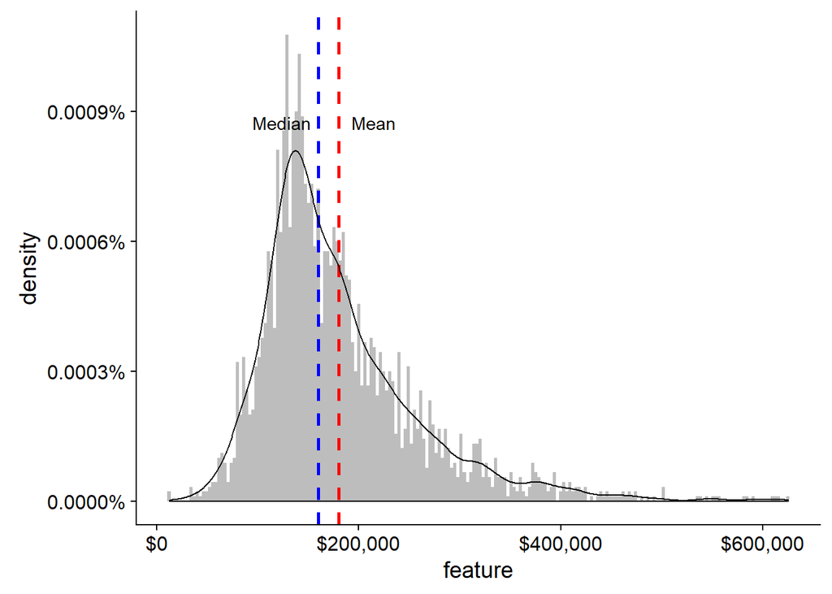

```r
library(repr)
options(repr.plot.width=20, repr.plot.height=8)
hist_with_kde <- function (feature) {
    plot <- qplot(feature, geom="histogram", bins=200, alpha=I(.4), y = ..density..)+
        geom_vline(aes(xintercept=mean(feature, rm.na=T)), color="red", linetype="dashed", size=1)+
        geom_vline(aes(xintercept=median(feature)), color="blue", linetype="dashed", size=1)+
       annotate(geom = 'text', x = 215000, y = 0.00000875, label = 'Mean') +
        annotate(geom = 'text', x = 124000, y = 0.00000875, label = 'Median') +
        geom_density()+ scale_x_continuous(labels = scales::dollar) +
  scale_y_continuous(labels = scales::percent)
    return(plot)
}
hist_with_kde(Ames$SalePrice)
```

#### Pair plot for numerical features.

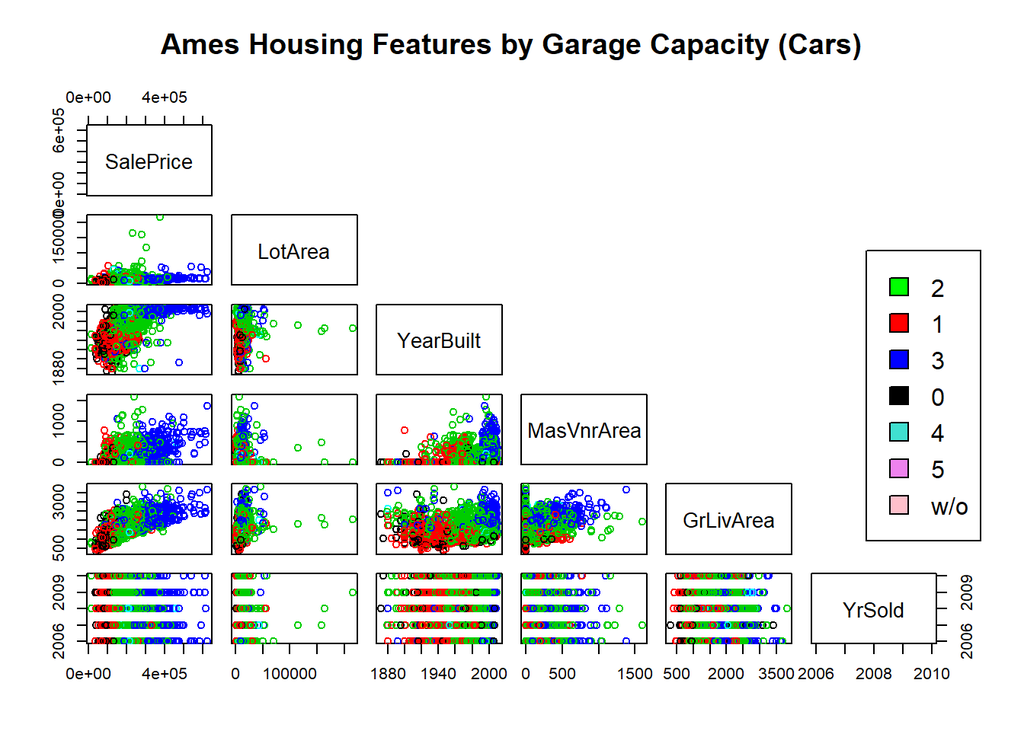

```r
AmesPairs <- AmesTibble[c(82, 6, 21, 28, 48, 79)]
pairs(AmesPairs, upper.panel = NULL, col = AmesTibble$GarageCars, main = 'Ames Housing Features by Garage Capacity (Cars)')
par(xpd = TRUE)
legend(0.9, 0.7, as.vector(unique(AmesTibble$GarageCars)), fill = c('green', 'red', 'blue', 'black', 'turquoise', 'violet', 'pink'))
```

#### Distribution plot of a numerical feature broken down by a categorical feature.Here the sales price is numeric and Neighborhood is a factor

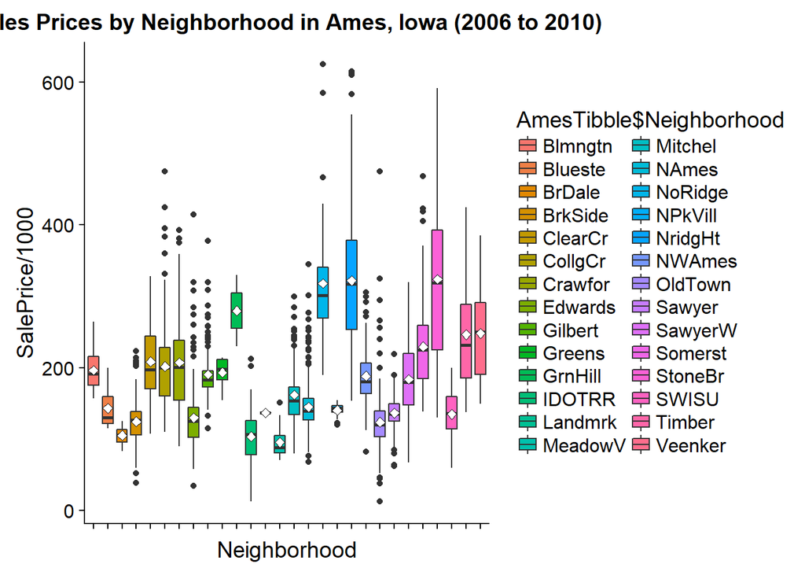

```r
ggplot(AmesTibble, aes(x = Neighborhood, y = SalePrice/1000)) +
  geom_boxplot(aes(fill = AmesTibble$Neighborhood)) +
  stat_summary(fun.y = 'mean', geom = 'point', shape = 23, size = 2, fill = 'white') +
  ggtitle("Sales Prices by Neighborhood in Ames, Iowa (2006 to 2010)") +
  theme(axis.text.x=element_blank())
```

### One Hot Encoding of categorical features

#### The factors needs to be converted into dummy variables.These dummy variables allows to use the factors as numerical values in the data set.Dummies are numeric representations of factors represented as zeroes and ones.

```r
AmesDummy <- dummy_cols(AmesTibble, remove_first_dummy = TRUE)
str(AmesDummy)
```

```
## Classes 'tbl_df', 'tbl' and 'data.frame':    2925 obs. of  342 variables:
##  $ Order                : int  1 2 3 4 5 6 7 8 9 10 ...
##  $ PID                  : int  526301100 526350040 526351010 526353030 527105010 527105030 527127150 527145080 527146030 527162130 ...
##  $ MSSubClass           : int  20 20 20 20 60 60 120 120 120 60 ...
##  $ MSZoning             : Factor w/ 7 levels "A (agr)","C (all)",..: 6 5 6 6 6 6 6 6 6 6 ...
##  $ LotFrontage          : int  141 80 81 93 74 78 41 43 39 60 ...
##  $ LotArea              : int  31770 11622 14267 11160 13830 9978 4920 5005 5389 7500 ...
##  $ Street               : Factor w/ 2 levels "Grvl","Pave": 2 2 2 2 2 2 2 2 2 2 ...
##  $ Alley                : Factor w/ 3 levels "Grvl","Pave",..: 3 3 3 3 3 3 3 3 3 3 ...
##  $ LotShape             : Factor w/ 4 levels "IR1","IR2","IR3",..: 1 4 1 4 1 1 4 1 1 4 ...
##  $ LandContour          : Factor w/ 4 levels "Bnk","HLS","Low",..: 4 4 4 4 4 4 4 2 4 4 ...
##  $ Utilities            : Factor w/ 3 levels "AllPub","NoSeWa",..: 1 1 1 1 1 1 1 1 1 1 ...
##  $ LotConfig            : Factor w/ 5 levels "Corner","CulDSac",..: 1 5 1 1 5 5 5 5 5 5 ...
##  $ LandSlope            : Factor w/ 3 levels "Gtl","Mod","Sev": 1 1 1 1 1 1 1 1 1 1 ...
##  $ Neighborhood         : Factor w/ 28 levels "Blmngtn","Blueste",..: 16 16 16 16 9 9 25 25 25 9 ...
```

[output cut: 87 more lines]

#### We remove the target and place it in another object since we dont have to scale the target,SalePrice.

```r
AmesDumNoTg <- AmesDummy[, -82]
AmesTarget <- AmesDummy[, 82]
names(Filter(is.factor, AmesDumNoTg))
```

```
##  [1] "MSZoning"      "Street"        "Alley"         "LotShape"
##  [5] "LandContour"   "Utilities"     "LotConfig"     "LandSlope"
##  [9] "Neighborhood"  "Condition1"    "Condition2"    "BldgType"
## [13] "HouseStyle"    "RoofStyle"     "RoofMatl"      "Exterior1st"
## [17] "Exterior2nd"   "MasVnrType"    "ExterQual"     "ExterCond"
## [21] "Foundation"    "BsmtQual"      "BsmtCond"      "BsmtExposure"
## [25] "BsmtFinType1"  "BsmtFinType2"  "Heating"       "HeatingQC"
## [29] "CentralAir"    "Electrical"    "BsmtFullBath"  "BsmtHalfBath"
## [33] "KitchenQual"   "Functional"    "FireplaceQu"   "GarageType"
## [37] "GarageFinish"  "GarageCars"    "GarageQual"    "GarageCond"
## [41] "PavedDrive"    "PoolQC"        "Fence"         "MiscFeature"
## [45] "SaleType"      "SaleCondition"
```

#### Removing the original columns and retaining the dummy variables.

```r
dropCols <- c("MSZoning", "Street", "Alley", "LotShape", "LandContour", "Utilities", "LotConfig", "LandSlope",
              "Neighborhood", "Condition1", "Condition2", "BldgType", "HouseStyle", "RoofStyle", "RoofMatl",
              "Exterior1st", "Exterior2nd", "MasVnrType", "ExterQual", "ExterCond", "Foundation", "BsmtQual",
              "BsmtCond", "BsmtExposure", "BsmtFinType1", "BsmtFinType2", "Heating", "HeatingQC", "CentralAir",
              "Electrical", "BsmtFullBath", "BsmtHalfBath", "KitchenQual", "Functional", "FireplaceQu", "GarageType",
              "GarageFinish", "GarageCars", "GarageQual", "GarageCond", "PavedDrive", "PoolQC", "Fence",
              "MiscFeature", "SaleType", "SaleCondition")
AmesDumNoTg <- AmesDumNoTg %>% dplyr::select(-one_of(dropCols))
dim(AmesDumNoTg)
```

```
## [1] 2925  295
```

#### Scaling the numerical features.

```r
AmesDumScale <- scale(AmesDumNoTg, center = TRUE, scale = TRUE)
AmesDumScaleDF <- as.tibble(AmesDumScale)
```

#### Visualising the transformation of numeric features.

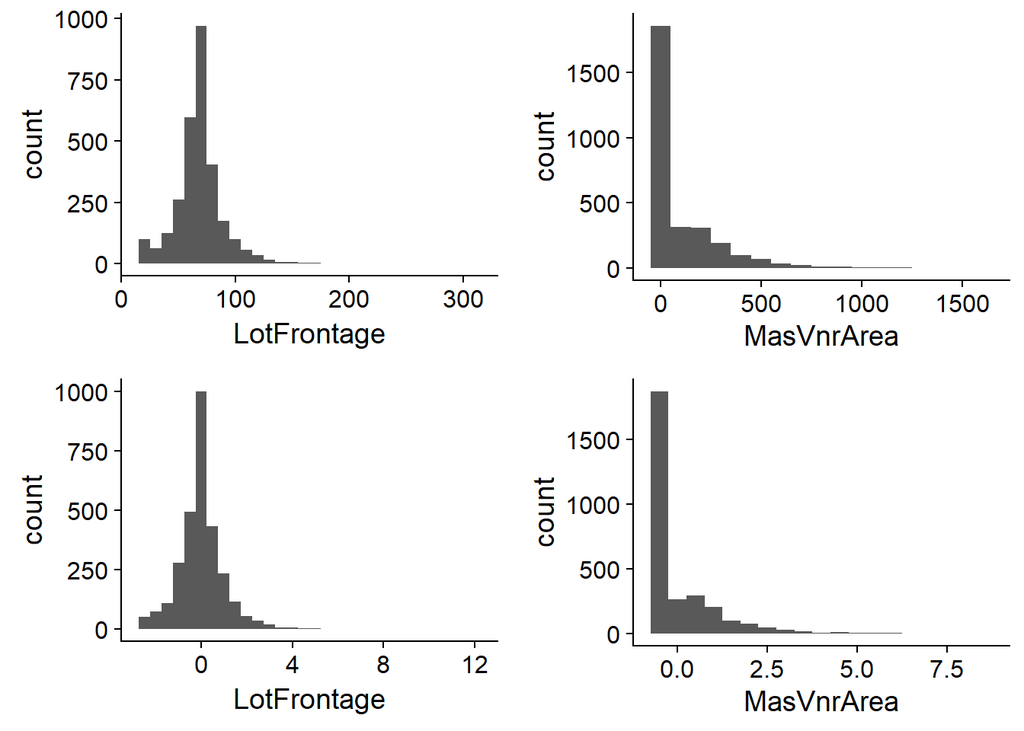

```r
p1 <- ggplot(AmesTibble, aes(x = LotFrontage)) + geom_histogram(binwidth = 10)
p2 <- ggplot(AmesDumScaleDF, aes(x = LotFrontage)) + geom_histogram(binwidth = .5)
p3 <- ggplot(AmesTibble, aes(x = MasVnrArea)) + geom_histogram(binwidth = 100)
p4 <- ggplot(AmesDumScaleDF, aes(x = MasVnrArea)) + geom_histogram(binwidth = .5)
p5 <- ggplot(AmesTibble, aes(x = GrLivArea)) + geom_histogram(binwidth = 250)
p6 <- ggplot(AmesDumScaleDF, aes(x = GrLivArea)) + geom_histogram(binwidth = .5)
p7 <- ggplot(AmesTibble, aes(x = GarageArea)) + geom_histogram(binwidth = 100)
p8 <- ggplot(AmesDumScaleDF, aes(x = GarageArea)) + geom_histogram(binwidth = .45)
grid.arrange(p1, p3, p2, p4, nrow = 2)
```

### Applying Statistical techniques to identify the most important features.

```r
AmesDumScaleDF <- cbind(AmesTarget, AmesDumScaleDF)
```

#### A linear model built to identify the top 10 features, based on the value of the estimates each feature is assigned by the model.

```r
lmRating <- lm(SalePrice ~ . , AmesDumScaleDF)
lmCoefs <- tidy(lmRating)
lmCoefs$abs_est <- sqrt(lmCoefs$estimate^2)
lmCoefsAbs <- lmCoefs[-c(2:5)]
lmCoefsAbs <- lmCoefsAbs[-1,]
head(lmCoefsAbs[order(-lmCoefsAbs$abs_est), ], 10)
```

```
##                    term    abs_est
## 15          TotalBsmtSF 123832.457
## 14            BsmtUnfSF 120676.837
## 12           BsmtFinSF1 111546.428
## 13           BsmtFinSF2  44164.501
## 17            X2ndFlrSF  26455.530
## 16            X1stFlrSF  20341.765
## 123 Exterior1st_VinylSd  11822.809
## 32             PoolArea   9797.808
## 9             YearBuilt   9595.549
## 7           OverallQual   8795.169
```

#### Using Lasso to identify the top 10 important features.The effort is made using both Gaussian and Poisson distribution.The lambda value is to be minimized using cross validation.We can plot the values of lambda as they minimize across the features.

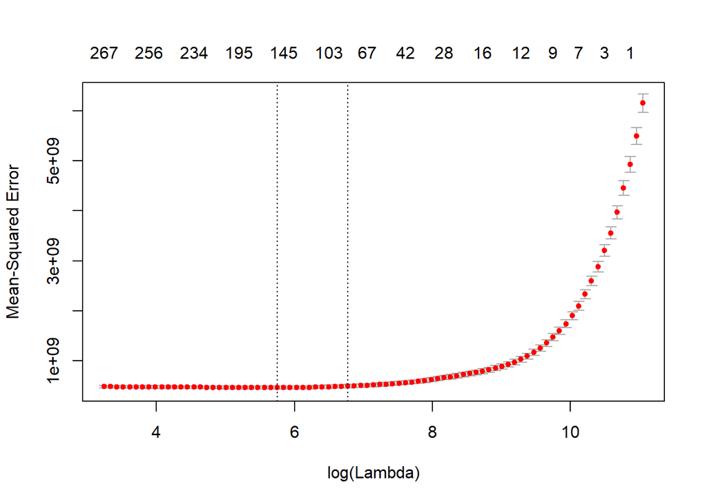

```r
x <- as.matrix(AmesDumScaleDF[, -1])
y <- as.matrix(AmesDumScaleDF[, 1])
set.seed(805)
cv.ridge.g <- cv.glmnet(x, y, family = 'gaussian')
plot(cv.ridge.g)
```

```r
cv.ridge.g$lambda.min
```

```
## [1] 314.7688
```

```r
cv.ridge.g$lambda.1se
```

```
## [1] 875.8628
```

```r
LassoCoefsG <- coef(cv.ridge.g, s = cv.ridge.g$lambda.min)
LassoCoefsG <- tidy(LassoCoefsG)
LassoCoefsG$abs_est <- sqrt(LassoCoefsG$value^2)
LassoCoefsG <- LassoCoefsG[-c(2:3)]
LassoCoefsG <- LassoCoefsG[-1,]
head(LassoCoefsG[order(-LassoCoefsG$abs_est), ], 10)
```

```
##                 row   abs_est
## 14        GrLivArea 27447.757
## 5       OverallQual 10820.683
## 7         YearBuilt  8055.729
## 10       BsmtFinSF1  7881.546
## 12      TotalBsmtSF  7649.133
## 6       OverallCond  5590.113
## 101 BsmtExposure_No  5443.750
## 142    GarageCars_3  5407.804
## 93     ExterQual_Ex  4984.161
## 99      BsmtQual_Ex  4873.956
```

#### We will use a lassos with a Poisson distribution to see if it yields different results.

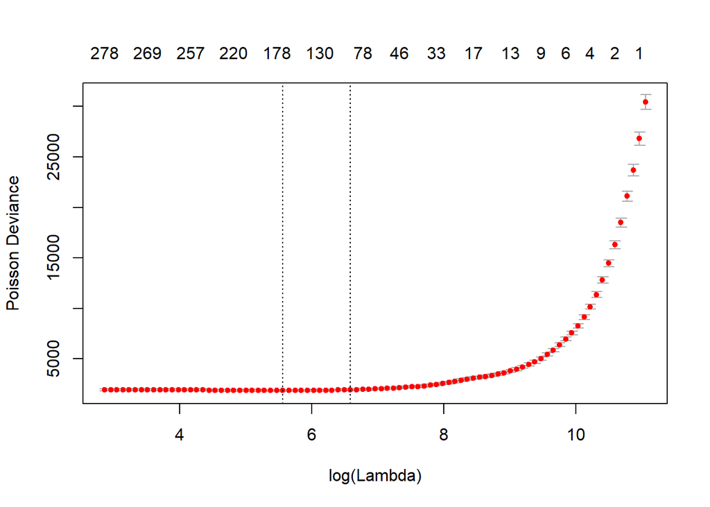

```r
set.seed(805)
cv.ridge.p <- cv.glmnet(x, y, family = 'poisson')
plot(cv.ridge.p)
```

```r
cv.ridge.p$lambda.min
```

```
## [1] 261.3266
```

```r
cv.ridge.p$lambda.1se
```

```
## [1] 727.1567
```

```r
LassoCoefsP <- coef(cv.ridge.p, s = cv.ridge.p$lambda.min)
LassoCoefsP <- tidy(LassoCoefsP)
LassoCoefsP$abs_est <- sqrt(LassoCoefsP$value^2)
LassoCoefsP <- LassoCoefsP[-c(2:3)]
LassoCoefsP <- LassoCoefsP[-1,]
head(LassoCoefsP[order(-LassoCoefsP$abs_est), ], 10)
```

```
##                     row    abs_est
## 17            GrLivArea 0.12727209
## 7           OverallQual 0.07690232
## 9             YearBuilt 0.05543208
## 14          TotalBsmtSF 0.04151936
## 8           OverallCond 0.03969011
## 12           BsmtFinSF1 0.03089923
## 24           GarageArea 0.02124546
## 57 Neighborhood_Crawfor 0.02013883
## 31          MSZoning_RM 0.01755621
## 10         YearRemodAdd 0.01685699
```

#### Out of the two lasso procedures the Poisson distribution yields better results since its lambda values are lower.

#### Using Gradient Boost Method

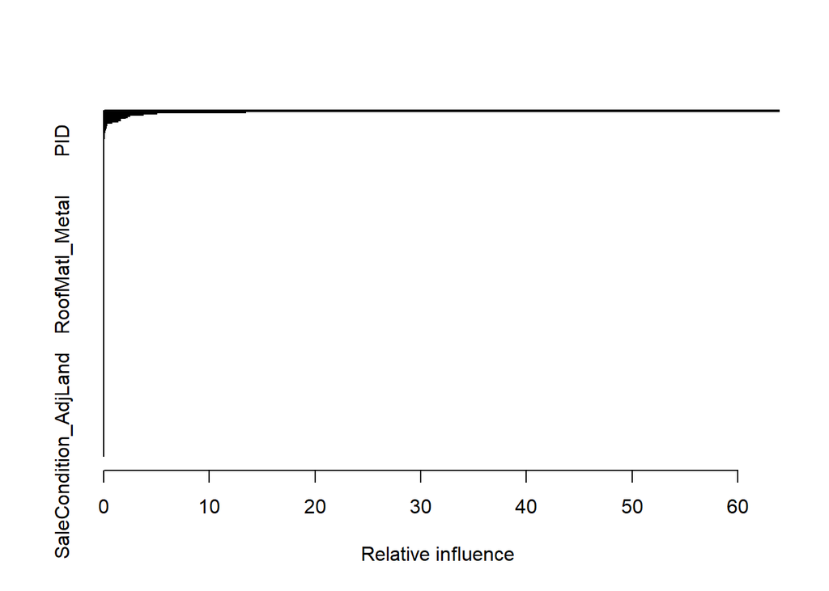

```
##                       var   rel.inf
## OverallQual   OverallQual 63.902825
## GrLivArea       GrLivArea 13.403990
## GarageCars_3 GarageCars_3  5.024785
## TotalBsmtSF   TotalBsmtSF  3.770163
## BsmtQual_Ex   BsmtQual_Ex  2.463716
## X1stFlrSF       X1stFlrSF  2.200320
## YearBuilt       YearBuilt  2.056381
## FullBath         FullBath  1.564799
## GarageArea     GarageArea  1.561966
## BsmtFinSF1     BsmtFinSF1  1.372851
```

```r
AmesBoost <- gbm(SalePrice ~ . , data = AmesDumScaleDF, distribution = 'gaussian',
                 n.trees = 100, shrinkage = 0.01, interaction.depth = 4)
head(summary(AmesBoost), 10)
```

#### With the above techniques applied we can observe the most important features.These features are selected for the Principal component analysis.PCA will determine which combinations of these features will be important for our analysis.

### Principal Component Analysis

#### The direction of PC1 indicates the line along which the data vary the most.PC2 is the linear combination of the same 11 features that is uncorrelated to PC1. Because of this, the direction of PC2 is perpendicular to the direction of PC1.Because PC1 and PC2 are orthogonal, they contain more information combined than either one does individually.The way PCA works, PC1 contains the most information.

```r
AmesPCAMeths <- as.tibble(AmesDumScaleDF[, c(15, 12, 17, 16, 33, 9, 19, 7, 250, 172, 27)])
AmesPCA <- pca(AmesPCAMeths, method = 'svd', center = FALSE, nPcs = 10)
summary(AmesPCA)
```

```
## svd calculated PCA
## Importance of component(s):
##                  PC1    PC2    PC3     PC4    PC5     PC6     PC7     PC8
## R2            0.3475 0.1622 0.1165 0.09114 0.0895 0.06085 0.05017 0.03759
## Cumulative R2 0.3475 0.5097 0.6261 0.71729 0.8068 0.86764 0.91781 0.95540
##                   PC9    PC10
## R2            0.02513 0.01913
## Cumulative R2 0.98053 0.99966
```

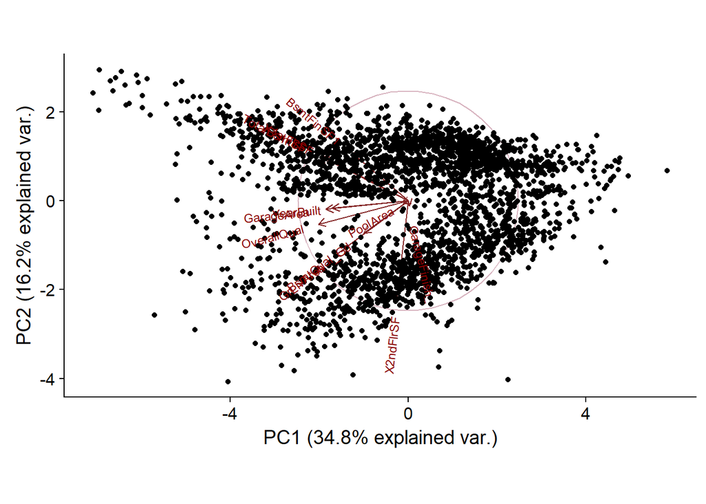

```r
AmesPCA2 <- prcomp(AmesPCAMeths)
ggbiplot::ggbiplot(AmesPCA2, obs.scale = 1, var.scale = 1, ellipse = TRUE, circle = TRUE) +
        scale_color_discrete(name = '') +
        theme(legend.direction = 'horizontal', legend.position = 'top')
```

```r
AmesLoad <- loadings(AmesPCA)
AmesLoad
```

```
##                        PC1         PC2         PC3          PC4
## TotalBsmtSF   -0.407110885  0.30133646  0.11564694 -0.044672592
## BsmtFinSF1    -0.262564471  0.32859116  0.03773039 -0.037380702
## X2ndFlrSF     -0.055648029 -0.69628202  0.19897909 -0.005747899
## X1stFlrSF     -0.389690383  0.29640162  0.27688594  0.010540842
## PoolArea      -0.024575262 -0.02014515  0.21234158  0.546053322
## YearBuilt     -0.353420991 -0.04937159 -0.50139447  0.029554025
## GrLivArea     -0.347973748 -0.38288860  0.40108966  0.005431124
## OverallQual   -0.418383877 -0.15932609 -0.06472074 -0.013869424
## GarageFinish_  0.005739956 -0.03578744  0.12299896 -0.834963740
## BsmtQual_Gd   -0.206589926 -0.22143457 -0.62532658 -0.005187737
## GarageArea    -0.382114964 -0.05844432  0.03513663  0.001416472
##                        PC5          PC6          PC7         PC8
## TotalBsmtSF   -0.040710516  0.126809447 -0.251356681  0.05493013
## BsmtFinSF1     0.001904234 -0.895003384  0.002438535 -0.03773754
## X2ndFlrSF     -0.085447971 -0.271191585 -0.046365097  0.01271417
## X1stFlrSF     -0.017752294  0.293377433 -0.266025506 -0.18792740
## PoolArea       0.804161478 -0.020104876  0.045560616  0.06195343
## YearBuilt      0.088816692  0.011615229  0.157107976  0.29110479
## GrLivArea     -0.089033563 -0.005184286 -0.255560937 -0.13932751
## OverallQual   -0.043970791  0.096638512  0.069674125  0.65563913
## GarageFinish_  0.530299252  0.024702249  0.046683470  0.03739033
## BsmtQual_Gd    0.209057499 -0.005208512 -0.407864699 -0.45927042
## GarageArea    -0.037090434  0.112830781  0.773587137 -0.45814604
##                       PC9         PC10
## TotalBsmtSF   -0.13700666  0.790809817
## BsmtFinSF1    -0.03859512 -0.127678418
## X2ndFlrSF      0.07008768  0.242236394
## X1stFlrSF      0.20408528 -0.438106369
## PoolArea      -0.02650978  0.045023693
## YearBuilt      0.70598266  0.066610124
## GrLivArea      0.21281184 -0.129320063
## OverallQual   -0.52170396 -0.277532248
## GarageFinish_  0.03046804 -0.007703467
## BsmtQual_Gd   -0.30233070 -0.069340566
## GarageArea    -0.15577603  0.051215887
```

```r
AmesMelt <- melt(AmesLoad)
AmesMelt
```

```
##                X1   X2        value
## 1     TotalBsmtSF  PC1 -0.407110885
## 2      BsmtFinSF1  PC1 -0.262564471
## 3       X2ndFlrSF  PC1 -0.055648029
## 4       X1stFlrSF  PC1 -0.389690383
## 5        PoolArea  PC1 -0.024575262
## 6       YearBuilt  PC1 -0.353420991
## 7       GrLivArea  PC1 -0.347973748
## 8     OverallQual  PC1 -0.418383877
## 9   GarageFinish_  PC1  0.005739956
## 10    BsmtQual_Gd  PC1 -0.206589926
## 11     GarageArea  PC1 -0.382114964
## 12    TotalBsmtSF  PC2  0.301336458
## 13     BsmtFinSF1  PC2  0.328591161
## 14      X2ndFlrSF  PC2 -0.696282024
```

[output cut: 96 more lines]

#### We can determine the important features from the below plot of standard deviations for each pincipal component and see the line breaks.

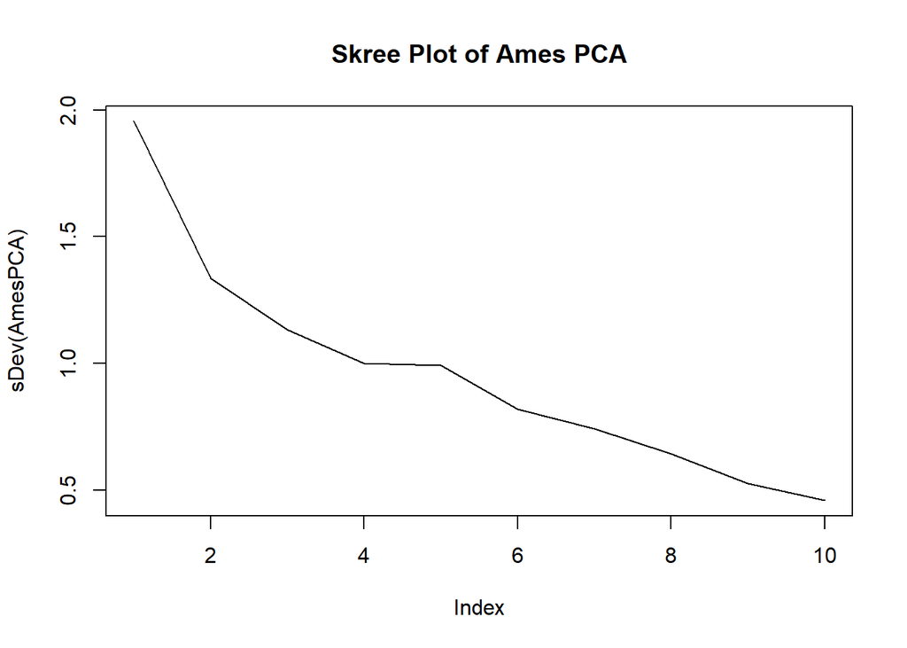

```r
plot(sDev(AmesPCA), type = "lines", main = 'Skree Plot of Ames PCA')
```

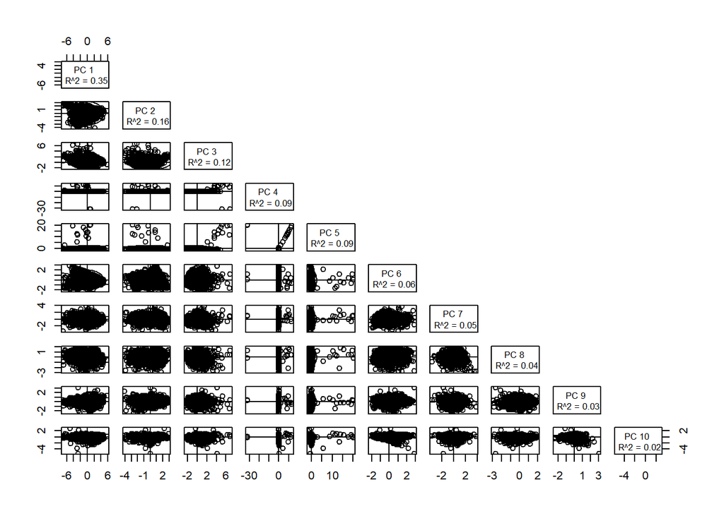

```r
plotPcs(AmesPCA)
```

#### From the skree plot we observe that three or four PCS are sufficient

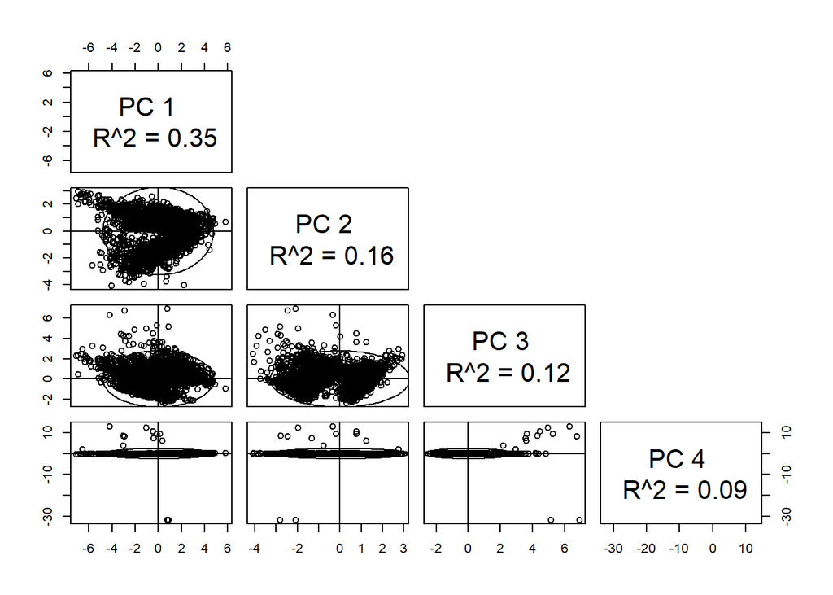

```r
plotPcs(AmesPCA, pcs = 1:4)
```

#### The following set of graphs compares PC1 to PC2, PC3, and PC4 in greater detail and includes analysis of the loadings.

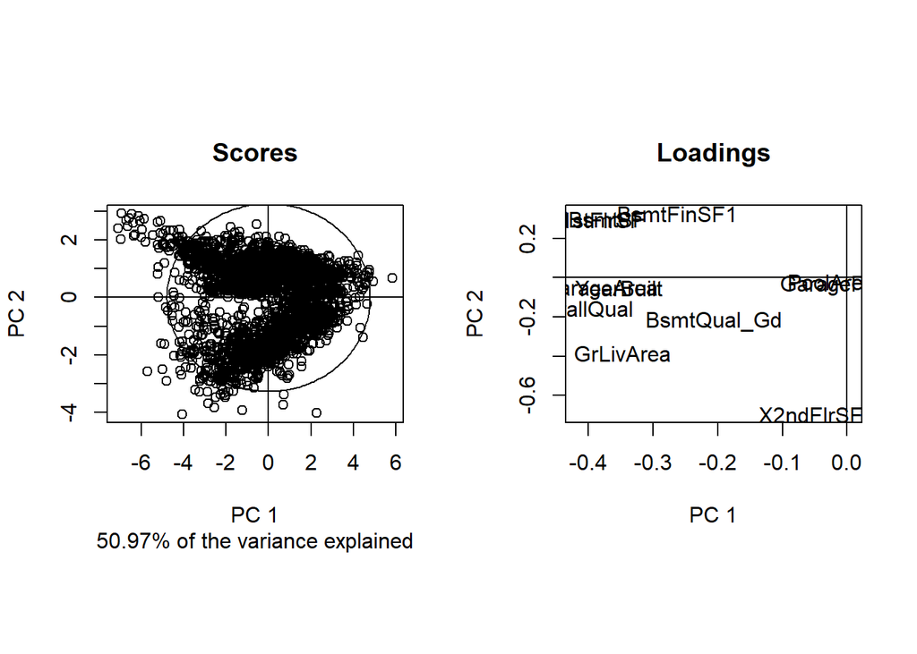

```r
slplot(AmesPCA, pcs = c(1, 2))
```

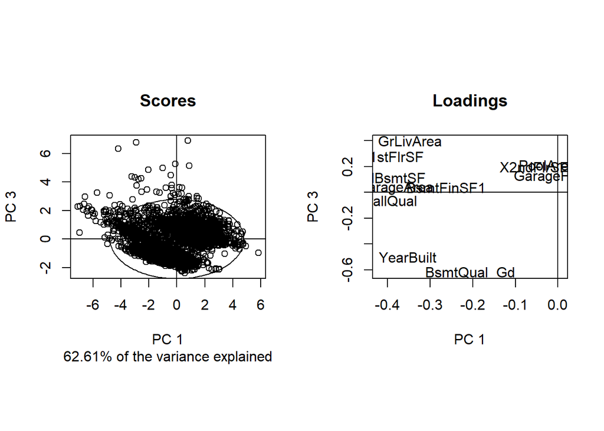

```r
slplot(AmesPCA, pcs = c(1, 3))
```

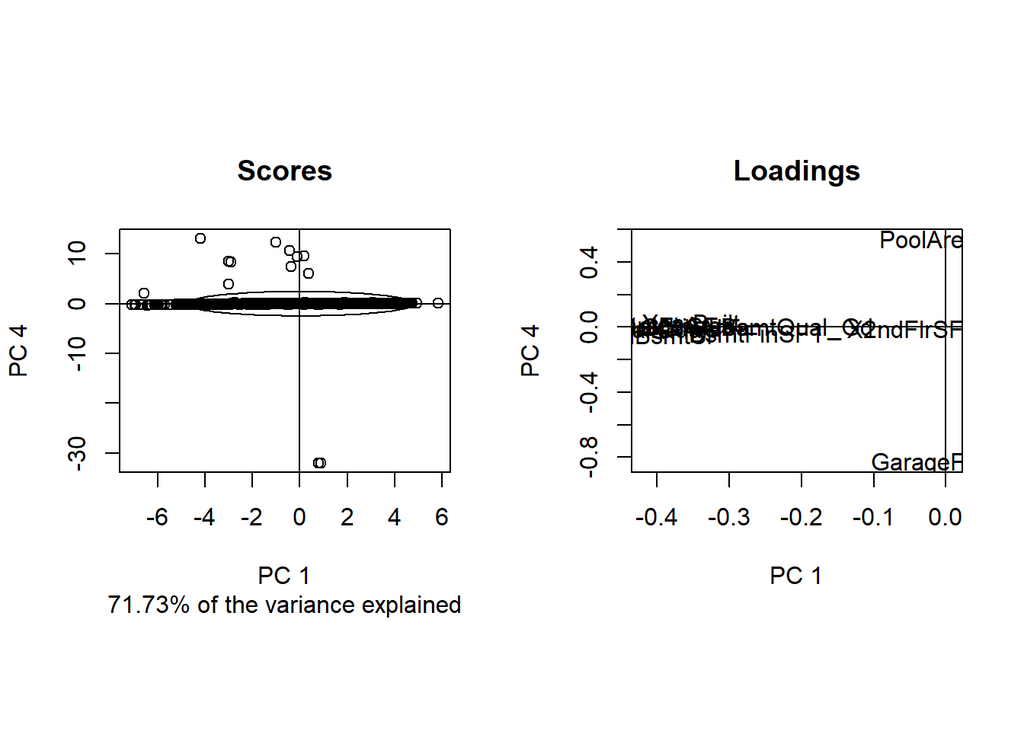

```r
slplot(AmesPCA, pcs = c(1, 4))
```

#### Below plot produces a visualization of loadings

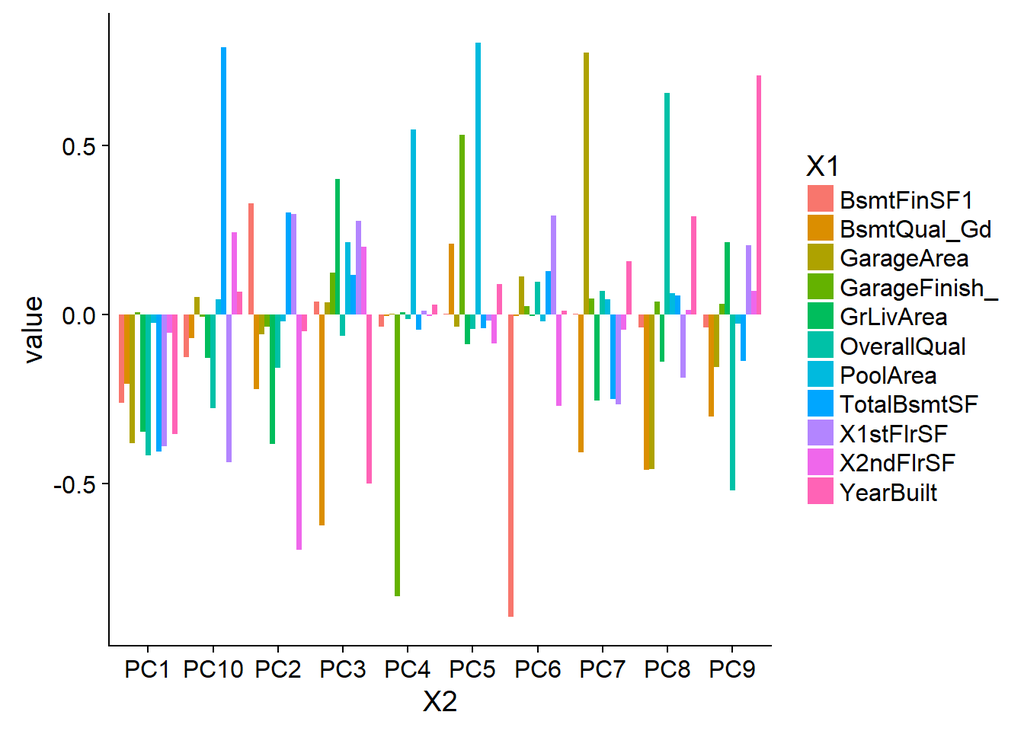

```r
ggplot(AmesMelt, aes(x = X2, y = value, fill = X1)) + geom_bar(stat = 'identity',
        position = 'dodge') + guides(fill = guide_legend(reverse = FALSE))
```

#### Cross validation of PCA results.

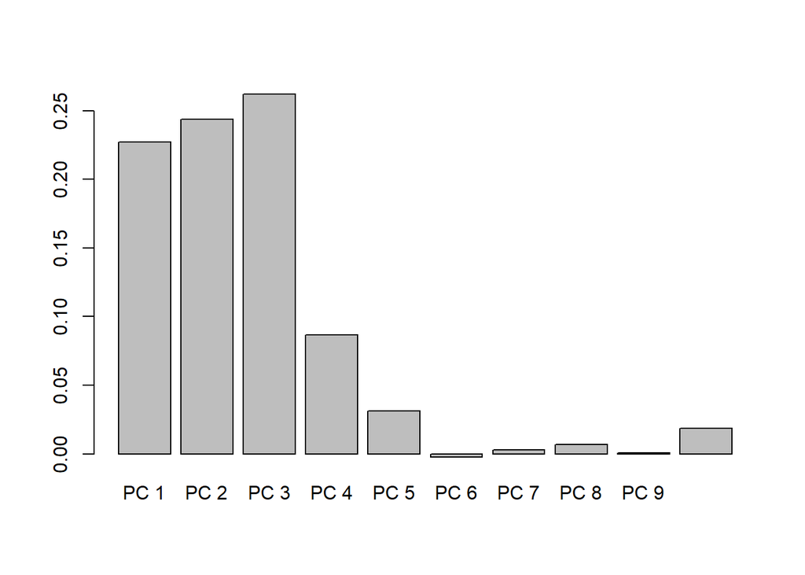

```r
q2svd <- Q2(AmesPCA, AmesPCAMeths, fold = 15, nruncv = 1)
barplot(q2svd)
```

#### The above results shows that only three or four PC’s are valuable in estimating the data structure.

#### In Clustering We have an idea of how many PCs are important to our understanding of the Ames data structure, so we can use clustering to confirm our findings. We will use a k-means cluster method so it is important to measure clusters in terms appropriate for k-means analysis.

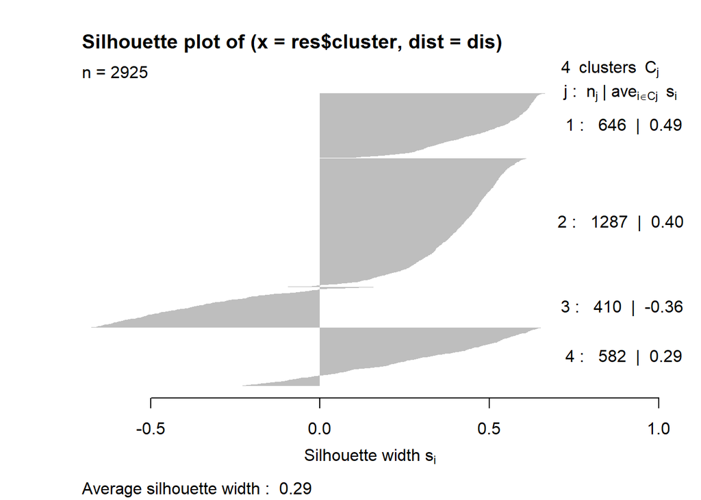

```r
dis <- dist(AmesPCAMeths)^2
res <- kmeans(AmesPCAMeths, 4)
sil <- silhouette(res$cluster, dis)
windows()
plot(sil)
```

```r
AmesCl <- kmeans(AmesPCAMeths, 4, nstart = 10)
AmesCl
```

```
## K-means clustering with 4 clusters of sizes 1221, 297, 729, 678
##
## Cluster means:
##   TotalBsmtSF BsmtFinSF1  X2ndFlrSF  X1stFlrSF     PoolArea  YearBuilt
## 1  -0.5707426 -0.3253959 -0.2250720 -0.5256137 -0.003944409 -0.8425715
## 2   1.7266551  1.4763918 -0.2421849  1.7832712  0.114569507  0.8664021
## 3   0.5889834  0.1944267 -0.7773613  0.5554645 -0.057435922  0.5231689
## 4  -0.3618124 -0.2697891  1.3472540 -0.4318449  0.018672223  0.5753219
##    GrLivArea OverallQual GarageFinish_ BsmtQual_Gd GarageArea
## 1 -0.5961920  -0.7452973   -0.02615329  -0.7488259 -0.6448636
## 2  1.1620378   1.4394914   -0.02615329  -0.2169675  1.2724602
## 3 -0.2602122   0.2050334   -0.02615329   0.6570372  0.2476735
## 4  0.8444247   0.4911647    0.08667617   0.7371322  0.3376163
##
## Clustering vector:
```

[output cut: 97 more lines]

#### We group the data into four clusters, each designated by a circle. The clusters are distinct but they tend to intermingle with the other clusters, resembling a Venn diagram with overlapping areas. The leftmost cluster seems particularly dispersed. Reducing the clusters to three did not improve things much so we will stick with four PCs, despite the fact that the clustering seems to be falling apart.

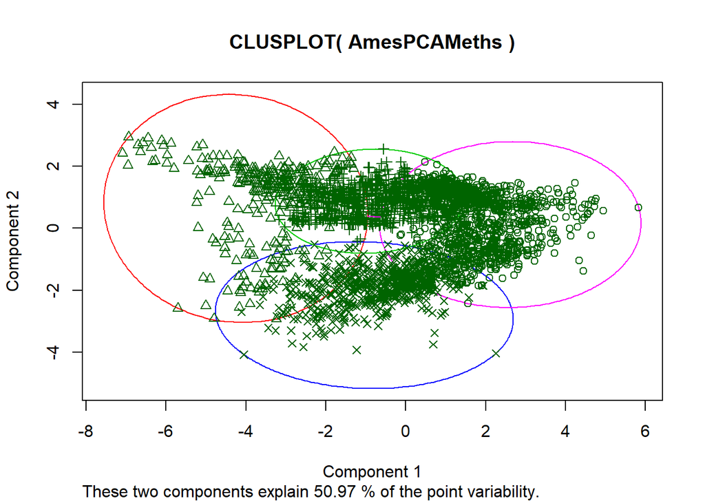

```r
clusplot(AmesPCAMeths, AmesCl$cluster, color = TRUE)
```